# Causal Inference

## Association vs Causation

- Question: What is causation? Why is it important? (text)

$$\\[0.5in]$$

- Are the following causal questions or association questions?
- Question: Which cancer treatments are best for which patients?
  - A. Causal
  - B. Association
  - C. Not sure

$$\\[0.5in]$$

- Question: Are people who take daily vitamin C less likely to get sick?
  - A. Causal
  - B. Association
  - C. Not sure

$$\\[0.5in]$$

- Question: Will a national gun law result in fewer homicides?
  - A. Causal
  - B. Association
  - C. Not sure

$$\\[0.5in]$$

- Question: Does increasing minimum wage reduce job openings?
  - A. Causal
  - B. Association
  - C. Not sure

$$\\[0.5in]$$

- Historically, there has been a lot of writing about what causation is
- Causation in statistics: Will changing $X$ also change $Y$?
- Association: Does knowing $X$ help to predict $Y$?
- If $X$ causes $Y$, then $X\not\perp Y$ ($X$ and $Y$ are associated)
- But, the converse is not true: it is possible for $X\not\perp Y$ but $X$ and $Y$ do not cause each other

## Simpson’s paradox

- How can statistics be misleading on causation?
- New infectious disease with high mortality rate
- Scientists develop an experimental treatment and give it to doctors to try out

```
##        treatment symptoms mortality
## 687 experimental   severe     alive
## 239 experimental   severe      died
## 530      placebo     mild      died
## 846      placebo     mild     alive
## 346 experimental     mild      died
## 634      placebo     mild     alive
## 509      placebo     mild     alive
## 475 experimental   severe     alive
## 213      placebo   severe      died
## 431      placebo     mild     alive
## 632 experimental     mild     alive
## 630 experimental   severe     alive
## 318      placebo   severe      died
## 991      placebo     mild     alive
## 648      placebo   severe     alive
## 880      placebo     mild     alive
## 136 experimental   severe      died
## 655 experimental   severe     alive
## 497      placebo     mild     alive
## 358      placebo     mild     alive
```

```
##
## experimental      placebo
##          487          513
```

```
##
##   mild severe
##    514    486
```

```
##
## alive  died
##   754   246
```

- The mortality rate for each group is below:

```r
table(df$treatment, df$mortality)[,2]/table(df$treatment)
```

```
##
## experimental      placebo
##    0.2648871    0.2280702
```

- The death rate is higher in the experimental treatment group than the placebo group
- Question: Can we conclude that the experimental drug in not effective?
  - A. Yes
  - B. No
  - C. Not sure

$$\\[0.5in]$$

- Taking a closer look, we stratify death rate by symptom severity:

```r
table(df$treatment, df$symptoms, df$mortality)[,,2]/table(df$treatment, df$symptoms)
```

```
##
##                      mild     severe
##   experimental 0.07352941 0.33903134
##   placebo      0.16402116 0.40740741
```

- Someone with severe symptoms is much more likely to die than someone with mild symptoms
- But, in both groups, the experimental treatment was associated with fewer deaths
- Question: What might this indicate? (select all that apply)
  - A. Mortality is greater with severe disease
  - B. The treatment is effective
  - C. Treatment type and severity are associated
  - D. None of the above

$$\\[0.5in]$$

- Let’s check if treatment type and severity are associated

```r
table(df$treatment, df$symptoms)
```

```
##
##                mild severe
##   experimental  136    351
##   placebo       378    135
```

```r
chisq.test(df$treatment, df$symptoms)
```

```
##
##  Pearson's Chi-squared test with Yates' continuity correction
##
## data:  df$treatment and df$symptoms
## X-squared = 207.58, df = 1, p-value < 2.2e-16
```

- Those with severe symptoms were more likely to be on the experimental treatment
- Timing matters here! Was severity taken before or after treatment?
- Neither scenario below is conclusive from the data, but knowing the time ordering can help rule one out

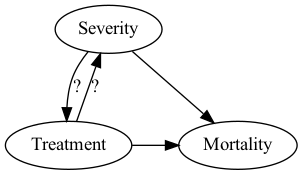

## Confounding

- Example: Sleeping with shoes on is associated with waking up with a headache
- Example: Yellow teeth and cancer are confounded by smoking
- Confounding: $X$ and $Y$ are confounded if they are both influenced by a third variable
- Example from last section: Assume that severity was taken before treatment was given

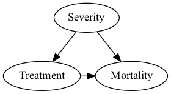

- There are two “open” paths from treatment to mortality:
  - treatment $\leftarrow$ severity $\rightarrow$ mortality
  - treatment $\rightarrow$ mortality
- Looking at the total association between treatment and mortality (without severity) will use include assocations from both paths
- Controlling for severity “blocks” the `treatment <- severity -> mortality` pathway
- We’re left with the direct causal path `treatment -> mortality`

### Confounding Simulations

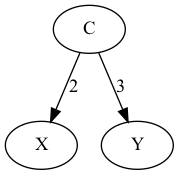

```r
size <- 500
C <- 10*runif(size)
X <- 2*C + rnorm(size)
Y <- 3*C + rnorm(size)

summary(lm(Y~X))
```

```
##
## Call:
## lm(formula = Y ~ X)
##
## Residuals:
##     Min      1Q  Median      3Q     Max
## -5.6491 -1.2526 -0.0418  1.2540  4.1460
##
## Coefficients:
##             Estimate Std. Error t value Pr(>|t|)
## (Intercept)   0.6102     0.1522    4.01 7.01e-05 ***
## X             1.4342     0.0131  109.52  < 2e-16 ***
## ---
## Signif. codes:  0 '***' 0.001 '**' 0.01 '*' 0.05 '.' 0.1 ' ' 1
##
## Residual standard error: 1.74 on 498 degrees of freedom
## Multiple R-squared:  0.9601, Adjusted R-squared:  0.9601
## F-statistic: 1.199e+04 on 1 and 498 DF,  p-value: < 2.2e-16
```

```r
summary(lm(Y~X+C))
```

```
##
## Call:
## lm(formula = Y ~ X + C)
##
## Residuals:
##      Min       1Q   Median       3Q      Max
## -2.81847 -0.63492  0.02683  0.65114  2.43640
##
## Coefficients:
##             Estimate Std. Error t value Pr(>|t|)
## (Intercept)  0.03361    0.08757   0.384    0.701
## X           -0.03018    0.04536  -0.665    0.506
## C            3.04750    0.09315  32.717   <2e-16 ***
## ---
## Signif. codes:  0 '***' 0.001 '**' 0.01 '*' 0.05 '.' 0.1 ' ' 1
##
## Residual standard error: 0.981 on 497 degrees of freedom
## Multiple R-squared:  0.9874, Adjusted R-squared:  0.9873
## F-statistic: 1.941e+04 on 2 and 497 DF,  p-value: < 2.2e-16
```

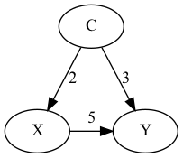

```r
Y <- 3*C + 5*X + rnorm(size)

summary(lm(Y~X))
```

```
##
## Call:
## lm(formula = Y ~ X)
##
## Residuals:
##    Min     1Q Median     3Q    Max
## -5.261 -1.139 -0.012  1.183  5.458
##
## Coefficients:
##             Estimate Std. Error t value Pr(>|t|)
## (Intercept)  0.65110    0.14861   4.381 1.44e-05 ***
## X            6.43596    0.01279 503.296  < 2e-16 ***
## ---
## Signif. codes:  0 '***' 0.001 '**' 0.01 '*' 0.05 '.' 0.1 ' ' 1
##
## Residual standard error: 1.7 on 498 degrees of freedom
## Multiple R-squared:  0.998,  Adjusted R-squared:  0.998
## F-statistic: 2.533e+05 on 1 and 498 DF,  p-value: < 2.2e-16
```

```r
summary(lm(Y~X+C))
```

```
##
## Call:
## lm(formula = Y ~ X + C)
##
## Residuals:
##     Min      1Q  Median      3Q     Max
## -3.2887 -0.6351 -0.0185  0.6507  2.9811
##
## Coefficients:
##             Estimate Std. Error t value Pr(>|t|)
## (Intercept)  0.09275    0.08704   1.066    0.287
## X            5.01797    0.04509 111.295   <2e-16 ***
## C            2.95101    0.09258  31.875   <2e-16 ***
## ---
## Signif. codes:  0 '***' 0.001 '**' 0.01 '*' 0.05 '.' 0.1 ' ' 1
##
## Residual standard error: 0.975 on 497 degrees of freedom
## Multiple R-squared:  0.9994, Adjusted R-squared:  0.9994
## F-statistic: 3.853e+05 on 2 and 497 DF,  p-value: < 2.2e-16
```

- Note: the covariate causal effect math only works here because the simulated data is linear. In the real world, we typically can’t assume linearity. This math doesn’t work without if the true data aren’t linear.
- In most real-world datasets, there will always be the possibility of latent confounding

## Sampling Bias

- [Sampling Bias](https://en.wikipedia.org/wiki/Sampling_bias) occurs when sample is collected in such a way that some members of the intended population have a lower or higher sampling probability than others.
- Sampling bias can lead to incorrect estimates when variables of interest influence sampling
- Example: In 1936, the American Literary Digest sent out two million surveys to its readers and predicted that Alf Landon would beat incumbent president, Franklin Roosevelt, by a landslide, but the opposite happened. This was because readers over-represented Republicans.
- [Example](https://catalogofbias.org/biases/collider-bias/): A researcher analysed data from 257 hospitalized individuals and detected an association between locomotor disease and respiratory disease (odds ratio 4.06). The researcher repeated the analysis in a sample of 2783 individuals from the general population and found no association (odds ratio 1.06)

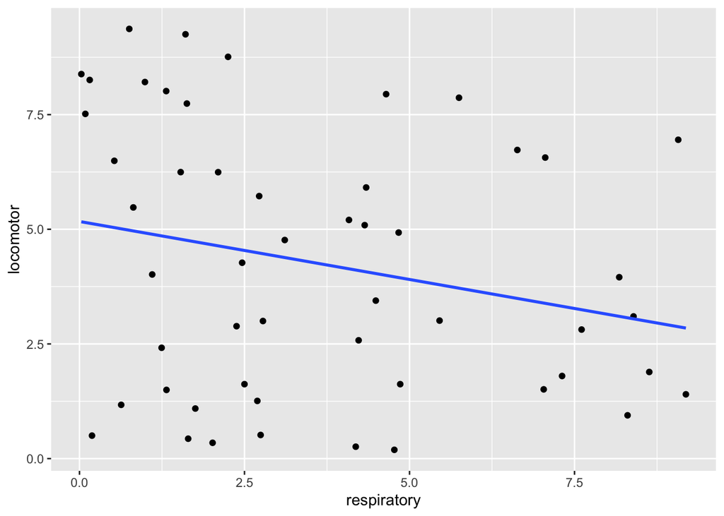

```r
size <- 100
locomotor <- 10*runif(size)
respiratory <- 10*runif(size)
hospitalized <- rbinom(size, 1, (locomotor+respiratory)/20)==0
df_all <- data.frame(locomotor, respiratory, hospitalized)
library(ggplot2)
ggplot(df_all[hospitalized==TRUE,], aes(respiratory, locomotor)) + geom_point() +
  geom_smooth(method = lm, se = FALSE)
```

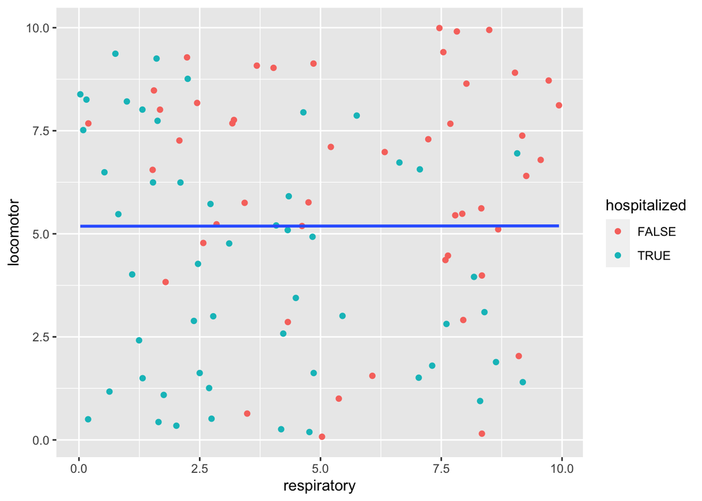

```r
ggplot(df_all, aes(respiratory, locomotor)) + geom_point(aes(color=hospitalized)) +
  stat_smooth(method=lm, se=FALSE)
```

- Sampling bias is an example of collider bias
- Here we are conditioning on hospitalization
- Even though locomotor and respiratory are independent, conditioning on a collider induces an association
- Conditioning on a collider “open” an association pathway

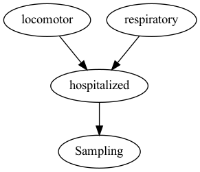

### Statistical Dependency and Causation

- If $A$ and $B$ are random variables and associated (dependent) $A\not\perp B$, it’s thought that there are 3 ways this can happen
  - Direct causation: OR
  - $A$ and $B$ are unmeasured confounding:

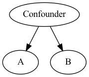

  - Collider bias: $A$ and $B$ both influence sampling

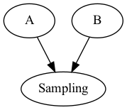

  - If we only have data for $A$ and $B$, we cannot distinguish between these case without more assumptions
- If there are more variables, we figure out more using conditional independence
  - Thinking about if knowing one variable gives information another
  - Variables: Drank too much alcohol last night, Woke up with a hangover, Woke up with shoes on

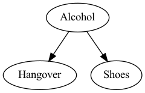

  - Hangover$\perp$Shoes?
  - Hangover$\perp$Shoes$|$Alcohol?
    - Given that someone drank too much alcohol last night, does knowing that they woke up with their shoes on give any information about if they have a hangover?
  - Variables: Burglary, Earthquake, Home motion detector

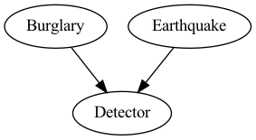

  - Burglary$\perp$Earthquake
  - Burglary$\perp$Earthquake$|$Detector?
    - Given that the home motion detector alerted, does knowing that there was no earthquake give any information about a burglary?

| Structure | Path type | $A,C$ independent/dependent? | $A,C$ conditionally independent/dependent given $B$ |
| --- | --- | --- | --- |
| Chain | $A \rightarrow B \rightarrow C$ | $A\not\perp C$ | $A\perp C\|B$ |
| Other Chain | $A \leftarrow B \leftarrow C$ | $A\not\perp C$ | $A\perp C\|B$ |
| Fork (Confounder) | $A \leftarrow B \rightarrow C$ | $A\not\perp C$ | $A\perp C\|B$ |
| Collider | $A \rightarrow B \leftarrow C$ | $A\perp C$ | $A\not\perp C\|B$ |

## GLMs, Causal Inference, and Prediction

- The goals for GLM inference models and causal inference models are similar in practice:
  - control for variables to approximate the causal influence of variables of interest
  - **if model assumptions are satisfied (linearity, no latent confounding, etc)**, standard GLMs will give causal parameter estimates
  - in this case, causal inference models *should* give similar parameter estimates to GLM estimates

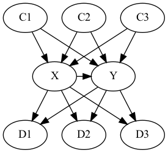

Question: If I want to use inference (causal or otherwise) to quantify the effect of $X$ on $Y$, which regression model should I use?

- A: Y ~ X
- B: Y ~ X + C1 + C2 + C3 + D1 + D2 + D3
- C: Y ~ X + C1 + C2 + C3
- D: Y ~ C1 + C2 + C3
- E: Y ~ X + D1 + D2 + D3

$$\\[0.5in]$$

- For GLMs and causal inference, should **only** control for variables that can *cause* our outcome
- For GLMs and causal inference, **should not** control for variables that are caused by the outcome (this can lead to collider bias)

#### Causal Inference

- If we do not control for *all* confounding variables, any association between $X$ and $Y$ present through the confounder pathway (red in image below) will likely be included in the parameter quantified by a model
- In *any* inference, we want to quantify the true causal parameter
  - Causal inference models make this easier by relaxing some assumptions

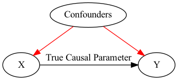

- Assumption of linear relationships within the data are likely not true (or at least hard to verify)
- Causal inference models make it possible to control for confounding variables in a non-linear setting
- Goal: Estimate a causal parameter of interest (when there are not linear relationships)
  - Causal parameters in our simulations are the parameters in the Bayesian network (DAG)
  - Causal parameter interpretation: if we were to change $X$, we should be able to use the causal parameter to accurately predict $Y$
  - Recall: when we did not control for confounding variables, the parameter estimates did not match the DAG
- Assumptions: no latent confounding (we have all confounding variables included in the data)

#### Prediction

- use all useful information in data to make a prediction
- we can use causes and effects
- we also want to use colliders because they also provide information
- General rule: use [Markov Blanket](https://en.wikipedia.org/wiki/Markov_blanket)
- For prediction, all variables in Markov blanket are useful for prediction, but not causation
  - If we changes causes, we should see changes in outcome
  - If we change variables in collider, we should not
- Note: Prediction methods try to find all variables in Markov blanket
  - This will depend on signal/noise ratio and model assumptions
- Given Markov Blanket, all other variables are conditionally independent from outcome
- If we *know* causal Bayesian network underlying a dataset, we should include all variables in Markov blanket and no others
  - Including variables not in Markov Blanket will be noise variables (given the Markov Blanket)

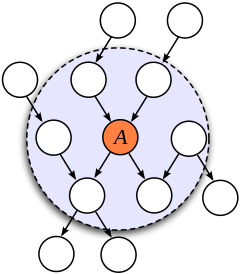

Markov Blanket Image from Wikipedia

In the image above, the Markov Blanket of $A$ is the set of white variable within the large circle

Questions:

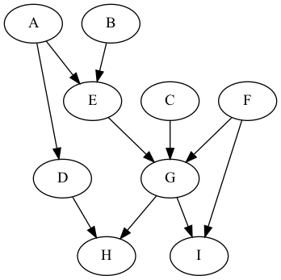

In the graph above, $D$ and $G$ are associated ($D \not\!\perp \!\!\! \perp G$)

- A. True
- B. False
- C. Not sure

$$\\[0.5in]$$
In the graph above, $D \perp \!\!\! \perp G |E$

- A. True
- B. False
- C. Not sure

$$\\[0.5in]$$
In the graph above, $D \perp \!\!\! \perp G |E, H$

- A. True
- B. False
- C. Not sure

$$\\[0.5in]$$

In the graph above, which variables should be used for inference on $G$ as the outcome? (text using capitals, no space, no comma, alphabetical order)

$$\\[0.5in]$$

In the graph above, which variables should be used for predicting $G$? (text using capitals, no space, no comma, alphabetical order)

$$\\[0.5in]$$
Using the graph above, which variables should be significant in the following regression $G\sim A+B+C+D+E+F+H+I$ (text using capitals, no space, no comma, alphabetical order)

## Evaluating Work Training Programs

- Manpower Demonstration Research Corporation was a federally and privately funded program implemented in the mid-1970s to provide work experience for a period of 6-18 months to individuals who faced economic and social problems prior to enrollment
- Program occurred between in 1976 and 1977
- Those selected to join the program participated in various types of work such as restaurant and construction
- Pre-treatment information was collected - earnings, education, age, ethnicity, marital status
- All observations here are from men
- See [Dehejia, R.H. and Wahba, S. (1999). Causal Effects in Nonexperimental Studies: Re-Evaluating the Evaluation of Training Programs. Journal of the American Statistical Association 94: 1053-1062](https://www.tandfonline.com/doi/pdf/10.1080/01621459.1999.10473858?casa_token=dsAisSiC-v4AAAAA:Auzr8KHp8-iB9Gy3T5o9hL-usKjKR1rne_TUvZDkHUCcI31OlVk_c0vwikXNTwQVYIKhhgSKqKXRJw)
- Goal: Determine causal efficacy of program on earnings
- Must control for potentially nonlinear confounding

```r
library(ggplot2)
data(lalonde)
dim(lalonde)
```

```
## [1] 614  10
```

```r
names(lalonde)
```

```
##  [1] "treat"    "age"      "educ"     "black"    "hispan"   "married"
##  [7] "nodegree" "re74"     "re75"     "re78"
```

```r
table(lalonde$treat)
```

```
##
##   0   1
## 429 185
```

```r
lalonde$treat <- ifelse(lalonde$treat == 1, TRUE, FALSE)

#age
tapply(lalonde$age, lalonde$treat, mean)
```

```
##    FALSE     TRUE
## 28.03030 25.81622
```

```r
t.test(lalonde$age ~ lalonde$treat)
```

```
##
##  Welch Two Sample t-test
##
## data:  lalonde$age by lalonde$treat
## t = 2.9911, df = 510.57, p-value = 0.002914
## alternative hypothesis: true difference in means between group FALSE and group TRUE is not equal to 0
## 95 percent confidence interval:
##  0.7598127 3.6683610
## sample estimates:
## mean in group FALSE  mean in group TRUE
##            28.03030            25.81622
```

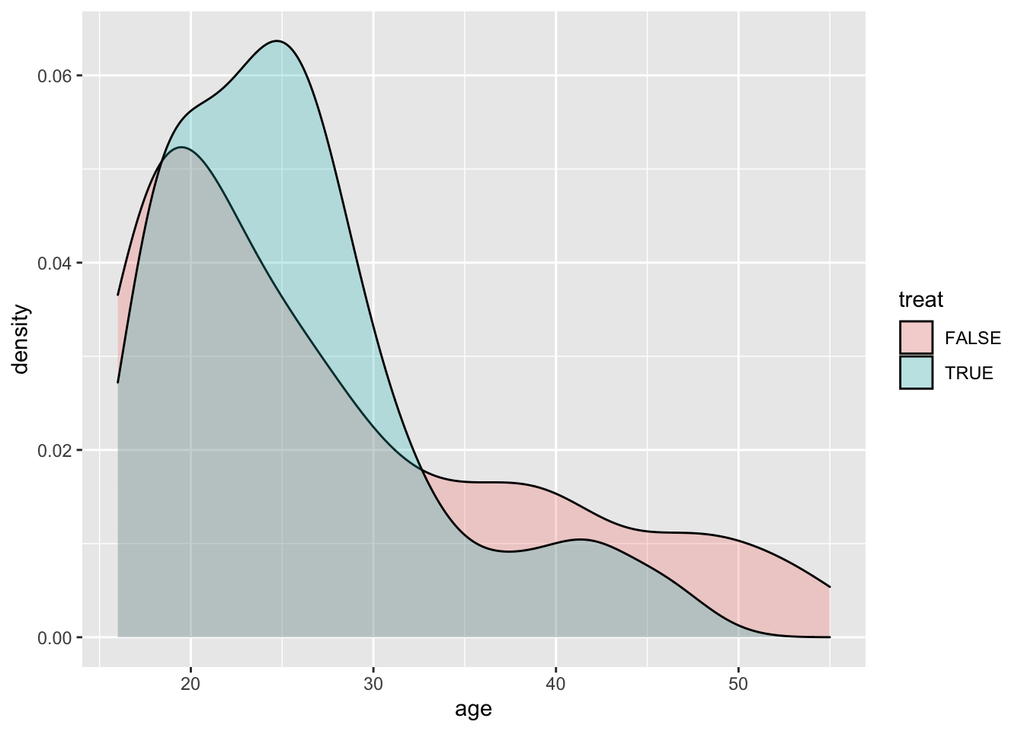

```r
ggplot(lalonde, aes(x=age, fill=treat)) +  geom_density(alpha=0.25)
```

```r
#educ
tapply(lalonde$educ, lalonde$treat, mean)
```

```
##    FALSE     TRUE
## 10.23543 10.34595
```

```r
t.test(lalonde$educ ~ lalonde$treat)
```

```
##
##  Welch Two Sample t-test
##
## data:  lalonde$educ by lalonde$treat
## t = -0.54676, df = 485.37, p-value = 0.5848
## alternative hypothesis: true difference in means between group FALSE and group TRUE is not equal to 0
## 95 percent confidence interval:
##  -0.5076687  0.2866393
## sample estimates:
## mean in group FALSE  mean in group TRUE
##            10.23543            10.34595
```

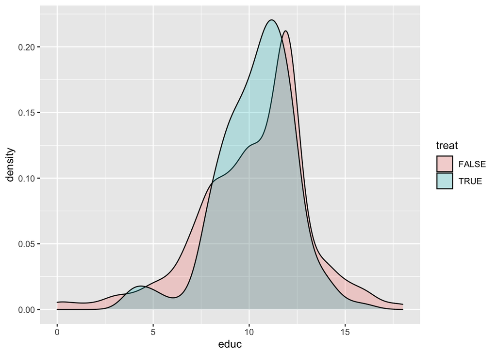

```r
ggplot(lalonde, aes(x=educ, fill=treat)) + geom_density(alpha=0.25)
```

```r
#black
table(lalonde$black, lalonde$treat)
```

```
##
##     FALSE TRUE
##   0   342   29
##   1    87  156
```

```r
chisq.test(lalonde$black, lalonde$treat)
```

```
##
##  Pearson's Chi-squared test with Yates' continuity correction
##
## data:  lalonde$black and lalonde$treat
## X-squared = 219.04, df = 1, p-value < 2.2e-16
```

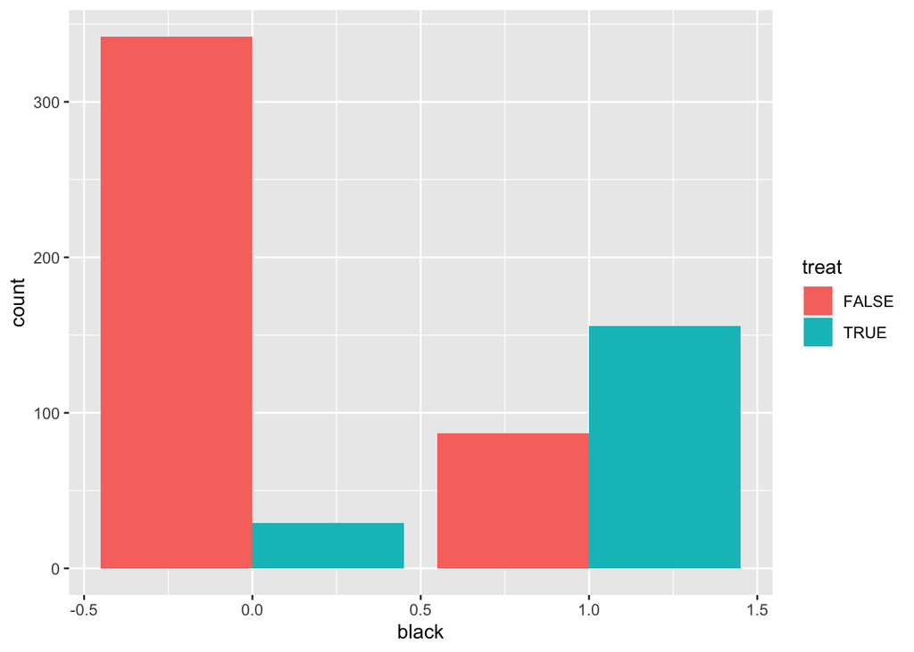

```r
ggplot(lalonde, aes(x=black, fill=treat)) + geom_bar(position = 'dodge')
```

```r
#hispan
table(lalonde$hispan, lalonde$treat)
```

```
##
##     FALSE TRUE
##   0   368  174
##   1    61   11
```

```r
chisq.test(lalonde$hispan, lalonde$treat)
```

```
##
##  Pearson's Chi-squared test with Yates' continuity correction
##
## data:  lalonde$hispan and lalonde$treat
## X-squared = 7.7664, df = 1, p-value = 0.005323
```

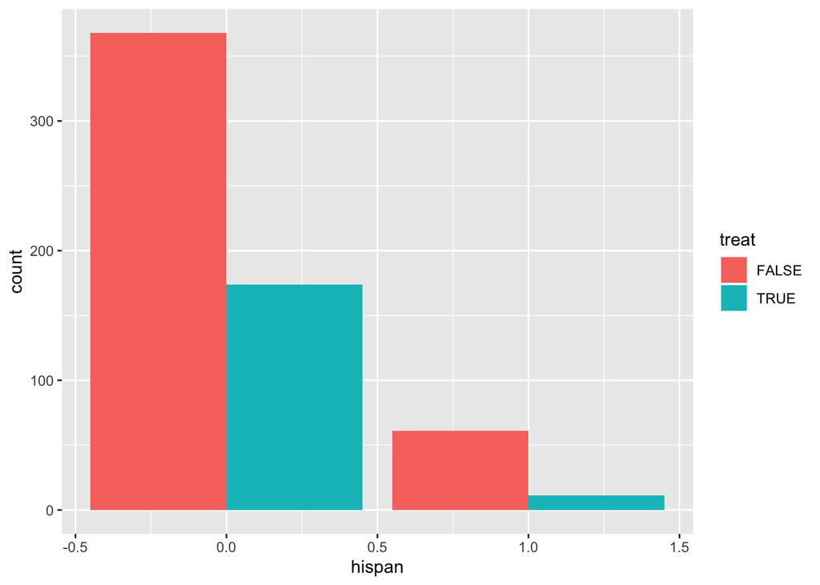

```r
ggplot(lalonde, aes(x=hispan, fill=treat)) +  geom_bar(position = 'dodge')
```

```r
#married
table(lalonde$married, lalonde$treat)
```

```
##
##     FALSE TRUE
##   0   209  150
##   1   220   35
```

```r
chisq.test(lalonde$married, lalonde$treat)
```

```
##
##  Pearson's Chi-squared test with Yates' continuity correction
##
## data:  lalonde$married and lalonde$treat
## X-squared = 54.428, df = 1, p-value = 1.613e-13
```

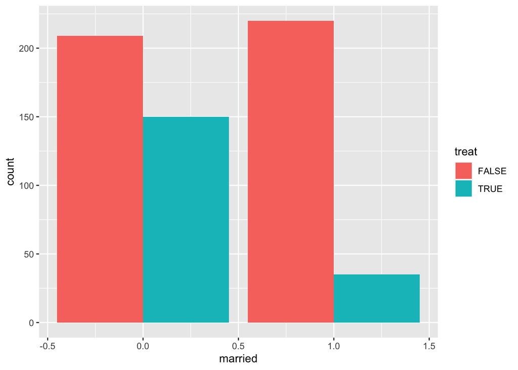

```r
ggplot(lalonde, aes(x=married, fill=treat)) +  geom_bar(position = 'dodge')
```

```r
#nodegree
table(lalonde$nodegree, lalonde$treat)
```

```
##
##     FALSE TRUE
##   0   173   54
##   1   256  131
```

```r
chisq.test(lalonde$nodegree, lalonde$treat)
```

```
##
##  Pearson's Chi-squared test with Yates' continuity correction
##
## data:  lalonde$nodegree and lalonde$treat
## X-squared = 6.4107, df = 1, p-value = 0.01134
```

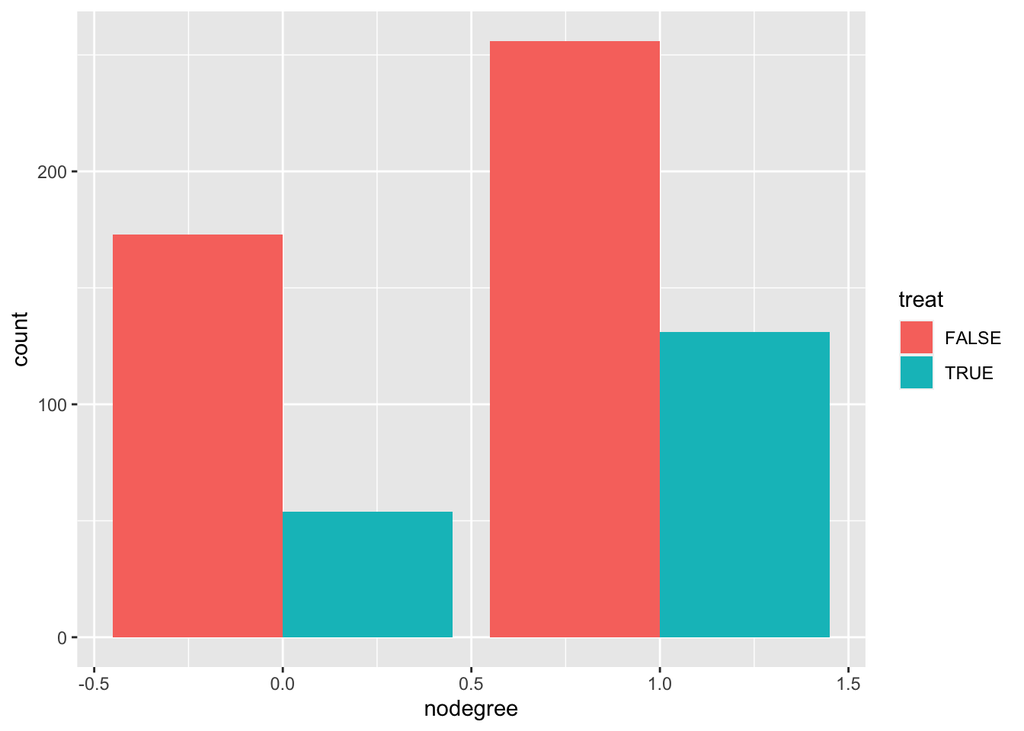

```r
ggplot(lalonde, aes(x=nodegree, fill=treat)) +  geom_bar(position = 'dodge')
```

```r
#re74
tapply(lalonde$re74, lalonde$treat, mean)
```

```
##    FALSE     TRUE
## 5619.237 2095.574
```

```r
t.test(lalonde$re74 ~ lalonde$treat)
```

```
##
##  Welch Two Sample t-test
##
## data:  lalonde$re74 by lalonde$treat
## t = 7.2456, df = 475.99, p-value = 1.748e-12
## alternative hypothesis: true difference in means between group FALSE and group TRUE is not equal to 0
## 95 percent confidence interval:
##  2568.067 4479.258
## sample estimates:
## mean in group FALSE  mean in group TRUE
##            5619.237            2095.574
```

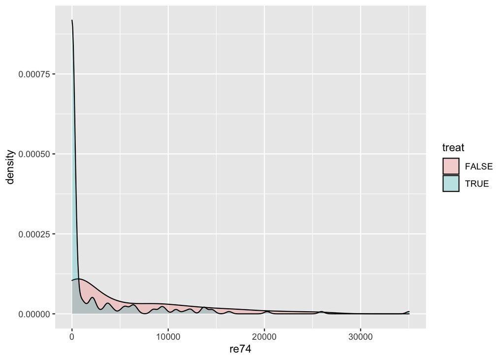

```r
ggplot(lalonde, aes(x=re74, fill=treat)) +  geom_density(alpha=0.25)
```

```r
#re75
tapply(lalonde$re75, lalonde$treat, mean)
```

```
##    FALSE     TRUE
## 2466.484 1532.055
```

```r
t.test(lalonde$re75 ~ lalonde$treat)
```

```
##
##  Welch Two Sample t-test
##
## data:  lalonde$re75 by lalonde$treat
## t = 3.2776, df = 356.22, p-value = 0.00115
## alternative hypothesis: true difference in means between group FALSE and group TRUE is not equal to 0
## 95 percent confidence interval:
##   373.742 1495.116
## sample estimates:
## mean in group FALSE  mean in group TRUE
##            2466.484            1532.055
```

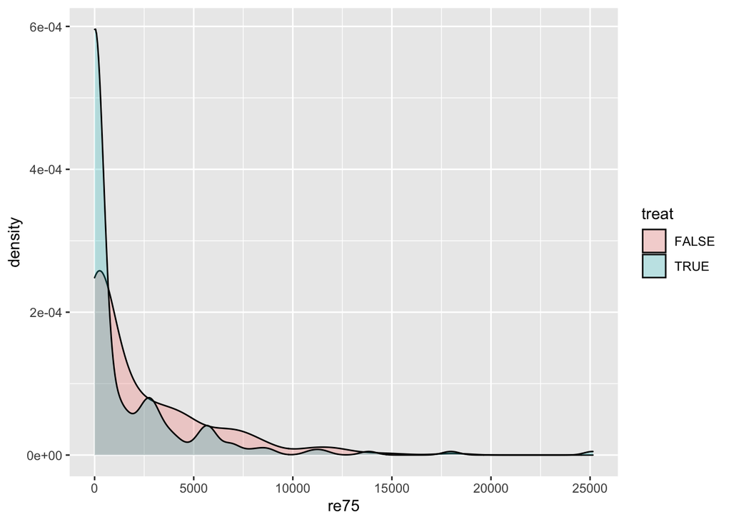

```r
ggplot(lalonde, aes(x=re75, fill=treat)) +  geom_density(alpha=0.25)
```

- Question: Is this a good way to present this information?
  - A. Yes
  - B. No

$$\\[0.5in]$$

- Question: How could this be improved? (conversation)

$$\\[0.5in]$$

## Quantifying Causal Effect with Counterfactuals

- Let $Y_i^1$ be the outcome under treatment for observation $i$ and let $Y_i^0$ be the outcome without treatment for observation $i$.
- Counterfactual results would be the results if the treatment were changed
- Common example: Does taking vitamin C prevent sickness:
  - $Y_i^1 = 1$ if $i$ were to take vitamin C and stays healthy
  - $Y_i^1 = 0$ if $i$ were to take vitamin C and gets sick
  - $Y_i^0 = 1$ if $i$ were not to take vitamin C and stays healthy
  - $Y_i^0 = 0$ if $i$ were not to take vitamin C and gets sick
- The causal effect for observation $i$ is
  $$Y_i^1 -
  Y_i^0$$
- Unfortunately, it’s not possible to any individual’s with and without treatment

```
##   A Y Y0 Y1
## 1 0 0  0 NA
## 2 0 0  0 NA
## 3 0 0  0 NA
## 4 0 0  0 NA
## 5 1 0 NA  0
## 6 1 1 NA  1
## 7 1 1 NA  1
## 8 1 1 NA  1
```

- In a population, the average causal effect (ATE) is
  $$\text{ATE} = E\left[Y^1 - Y^0\right] = E[Y^1] -
  E[Y^0]$$
- Estimated as
  $$\widehat{\text{ATE}} =
  \frac{1}{n} \sum_{i=1}^n\left(Y_i^1 - Y_i^0\right)$$
- Question: Is $E(Y^1|A=1)$ different from $E(Y|A=1)$?
  - A. Yes
  - B. No
  - C. Not sure

$$\\[0.5in]$$

- $E(Y^1|A=1)$ is the causal effect of treatment while $E(Y|A=1)$ is the association
- $Y^1 = Y^{A=1}$ and $Y^0 = Y^{A=0}$ assumes that $A$ is not influenced by any variables, measured or latent we are able to choose the counterfactual scenario

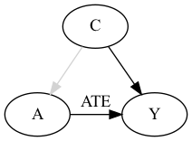

- No other variables influence $A$ when we consider $Y^1, Y^0$
- ATE can be interpreted as the average difference in outcome within the population that is attributed to $A$
- There may be other reasons $Y$ differs from person to person, like age, severity, etc
- Conditional Average Causal Effect (CATE): if $Z$ is another covariate,
  $$\text{CATE}_z = E[Y^1|Z=z] - E[Y^0|Z=z]$$
  is the average causal effect for group $Z=z$.

## Randomized Controlled Experiments or Trials

- When does a parameter estimate have a causal interpretation?
- Consider vaccine trails: a population is randomized to receive a test vaccine or placebo
- Single or double blind: participants (and sometimes researcher) are not told which group they are in
- Because of randomization, confounding is not possible and with a large enough sample, the two group will be statistically identical other than vaccine treatment
- Any difference in infection acquisition can be attributed to vaccination.
- Can estimate ATE:
  $$\begin{align}
  \widehat{\text{ATE}}
  &= E[Y^{\text{vaccine}}] - E[Y^{\text{placebo}}] \\
  &= \frac{1}{n} \sum_{i=1}^n Y_i^{\text{vaccine}} - \frac{1}{m}
  \sum_{j=1}^m Y_j^{\text{placebo}}
  \end{align}$$
- $H_0: \widehat{\text{ATE}} = 0, H_1: \widehat{\text{ATE}} > 0$
- Two sample t-test is sufficient

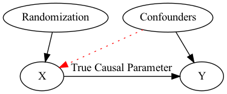

- Randomization: what would the treatment and control populations look like for the work training data if treatment were randomized?

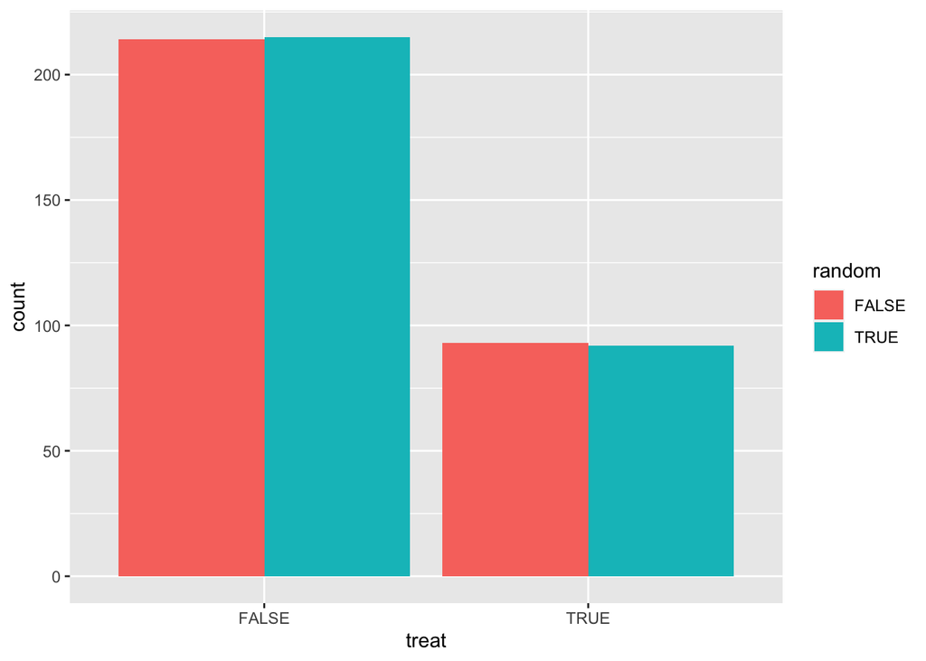

```r
set.seed(1234)
lalonde$random <- sample(rep(c(TRUE, FALSE), length.out=dim(lalonde)[1]))
ggplot(lalonde, aes(x=treat, fill=random)) + geom_bar(position = 'dodge')
```

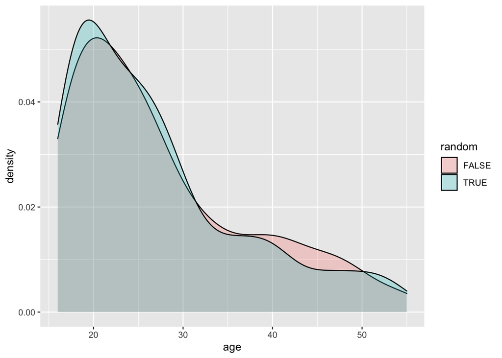

```r
ggplot(lalonde, aes(x=age, fill=random)) +  geom_density(alpha=0.25)
```

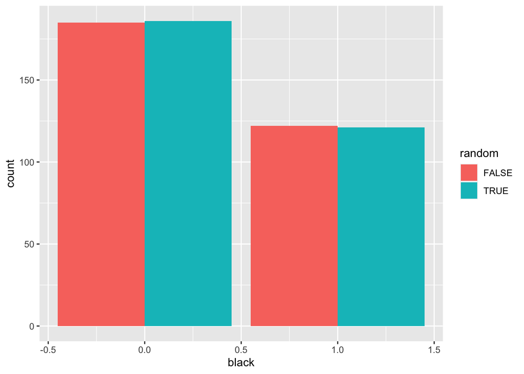

```r
ggplot(lalonde, aes(x=black, fill=random)) + geom_bar(position = 'dodge')
```

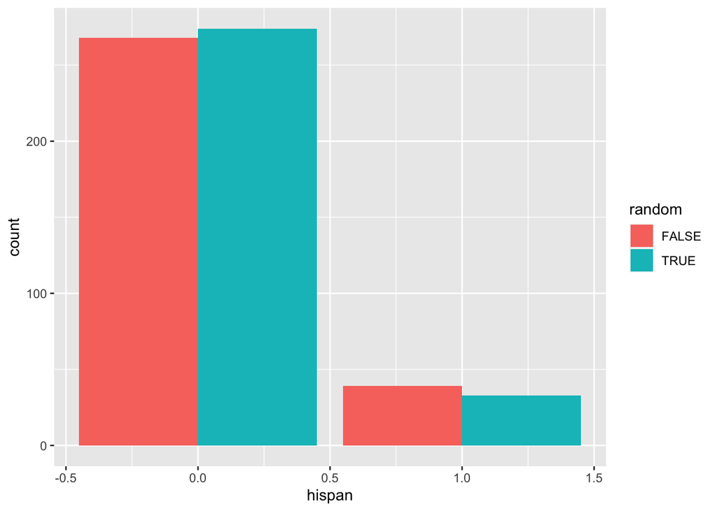

```r
ggplot(lalonde, aes(x=hispan, fill=random)) + geom_bar(position = 'dodge')
```

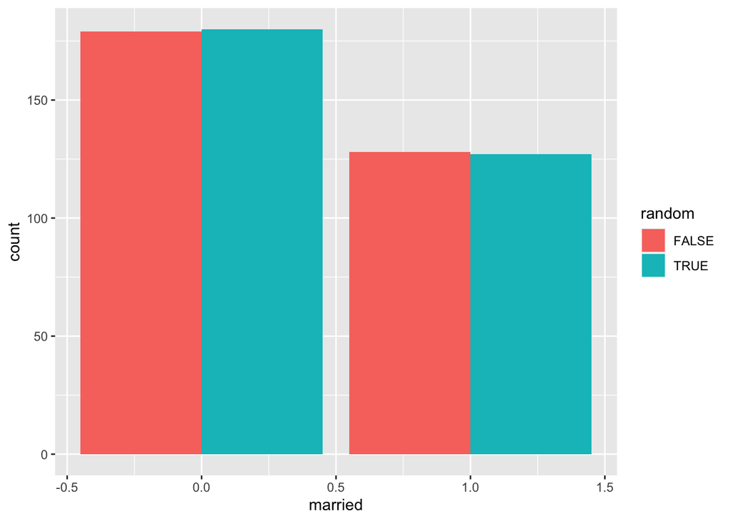

```r
ggplot(lalonde, aes(x=married, fill=random)) + geom_bar(position = 'dodge')
```